# Sesión 2 · Probabilidad y Teorema de Bayes

Nivelación Estadística y Probabilidades — Doctorados en Políticas Públicas y en Ciencias de la Complejidad Social · Universidad del Desarrollo

Amaru Agüero Jiménez (a.agueroj@udd.cl)

marzo de 2026

## Panorama de la sesión

| Bloque | Concepto clave | Herramienta en R |
| --- | --- | --- |
| Fundamentos | Espacio muestral, eventos, axiomas | `sample()` |
| Reglas | Adición, complemento, multiplicación | aritmética vectorizada |
| Condicional | Conjunta, marginal, condicional, independencia | `table()`, `prop.table()` |
| Bayes | Prior, verosimilitud, posterior | cálculo directo, `rbinom()` |
| Simulación | Monte Carlo, ley de grandes números | `set.seed()`, `cumsum()` |
| Aplicaciones | Diagnóstico, focalización, fraude | `ggplot2` |

**Idea de la sesión:** la probabilidad es el lenguaje de la incertidumbre. Toda decisión de política — focalizar un subsidio, activar una alerta de fraude, interpretar un test — es una apuesta condicionada a información parcial.

## Experimento aleatorio, espacio muestral y eventos

- **Experimento aleatorio:** proceso cuyo resultado no puede predecirse con certeza, pero cuyos resultados posibles son conocidos.
- **Espacio muestral** $\Omega$: conjunto de todos los resultados posibles.
- **Evento** $A \subseteq \Omega$: subconjunto de resultados. Evento seguro: $\Omega$; imposible: $\emptyset$.

| Experimento | Espacio muestral $\Omega$ | Evento de interés $A$ |
| --- | --- | --- |
| Lanzar un dado | $\{1, 2, 3, 4, 5, 6\}$ | par $= \{2, 4, 6\}$ |
| Encuestar un hogar | {recibe subsidio, no recibe} | recibe |
| Fiscalizar una empresa | {cumple, no cumple} | no cumple |
| Seguir a un beneficiario | {termina el programa, deserta} | deserta |

Definir $\Omega$ con precisión es el primer paso de todo modelo: ¿qué cuenta como “deserción”? ¿Quiénes componen la población fiscalizable? Ambigüedad aquí invalida cualquier probabilidad posterior.

## Operaciones entre eventos: el diagrama de Venn

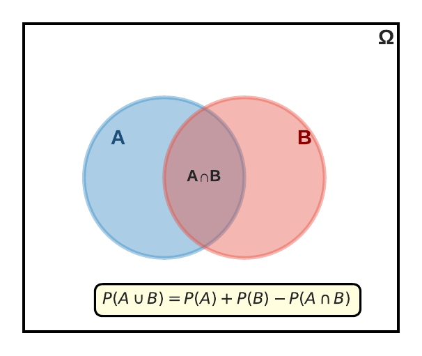

**Álgebra de eventos:**

- **Unión** $A \cup B$: ocurre $A$ **o** $B$ (o ambos)
- **Intersección** $A \cap B$: ocurren $A$ **y** $B$
- **Complemento** $A^c$: no ocurre $A$
- **Disjuntos**: $A \cap B = \emptyset$ (no pueden ocurrir juntos)

**Leyes de De Morgan:**
$$(A \cup B)^c = A^c \cap B^c$$
$$(A \cap B)^c = A^c \cup B^c$$

“No recibe ningún beneficio” $=$ “no recibe A **y** no recibe B”.

## Las operaciones, una a una

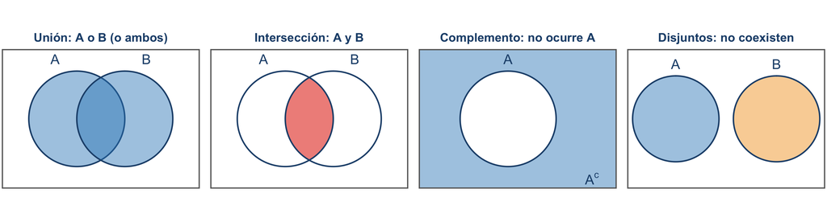

En el ejemplo de la comuna: unión $=$ recibe al menos un beneficio; intersección $=$ recibe ambos; complemento $=$ no recibe vivienda; disjuntos $=$ categorías excluyentes de un registro.

**Intuición**

Unión: pertenecer a al menos uno de los dos clubes. Intersección: estar inscrito en ambos a la vez. Complemento: todo el resto de la sala. Disjuntos: clubes que no comparten ningún miembro.

## Axiomas de Kolmogorov: las tres reglas del juego

Una medida de probabilidad es una función $P$ que asigna un número a cada evento y cumple:

| Axioma | Enunciado |
| --- | --- |
| 1. No negatividad | $P(A) \geq 0$ para todo evento $A$ |
| 2. Normalización | $P(\Omega) = 1$ |
| 3. Aditividad | Si $A_1, A_2, \ldots$ son disjuntos: $P\left(\bigcup_i A_i\right) = \sum_i P(A_i)$ |

**Consecuencias inmediatas** (todo lo demás se deriva de estos tres axiomas):

$$P(\emptyset) = 0 \qquad P(A^c) = 1 - P(A) \qquad A \subseteq B \Rightarrow P(A) \leq P(B) \qquad P(A) \leq 1$$

Si un informe reporta probabilidades que suman más de 1 sobre categorías excluyentes, o “riesgos” negativos, viola los axiomas: el error es de construcción, no de interpretación.

## ¿Qué es una probabilidad? Tres interpretaciones

| Enfoque | Definición | Ejemplo en políticas públicas |
| --- | --- | --- |
| Clásica (Laplace) | casos favorables / casos posibles | dado justo: $P(\text{par}) = 3/6$ |
| Frecuentista | límite de la frecuencia relativa al repetir el experimento | tasa histórica de deserción escolar |
| Subjetiva (bayesiana) | grado de creencia coherente, actualizable con evidencia | prob. de que una reforma se apruebe este año |

- Las tres obedecen los **mismos axiomas**: difieren en qué se puede modelar, no en la matemática.
- Eventos únicos (¿se aprobará la reforma?) no tienen frecuencia: solo admiten lectura bayesiana.
- Esta sesión usa las tres: conteo (tablas), frecuencia (simulación) y actualización (Bayes).

**Intuición**

Tres maneras de responder “¿qué tan seguro estoy?”: contar casos como en un juego de mesa, mirar qué pasó las mil veces anteriores, o decidir cuánto apostaría hoy y revisarlo al ver los datos.

## Reglas de adición y complemento

$$P(A \cup B) = P(A) + P(B) - P(A \cap B) \qquad \qquad P(A^c) = 1 - P(A)$$

**Ejemplo:** en una comuna, 30% de los hogares recibe subsidio de vivienda ($A$), 25% recibe apoyo alimentario ($B$) y 10% recibe ambos.

```r
pA <- 0.30; pB <- 0.25; pAB <- 0.10
c(al_menos_uno = pA + pB - pAB,
  solo_vivienda = pA - pAB,
  ninguno = 1 - (pA + pB - pAB))
```

```
 al_menos_uno solo_vivienda       ninguno
         0.45          0.20          0.55
```

- Sumar $0.30 + 0.25 = 0.55$ **sobreestima**: cuenta dos veces al 10% que recibe ambos.
- Solo si $A$ y $B$ son disjuntos vale $P(A \cup B) = P(A) + P(B)$.
- El complemento es el atajo clásico: $P(\text{al menos un beneficio}) = 1 - P(\text{ninguno})$.

**Intuición**

Sumar los dos grupos cuenta dos veces a quienes están en ambos círculos del Venn: por eso se descuenta una vez la zona compartida.

## Ley de grandes números: frecuencia → probabilidad

```r
set.seed(2026)
n <- 10000
dado <- sample(1:6, n,
               replace = TRUE)
frec <- cumsum(dado == 6) / (1:n)
tibble(n = 1:n, frec = frec) %>%
  ggplot(aes(n, frec)) +
  geom_line(color = celeste) +
  geom_hline(yintercept = 1/6,
             color = rojo,
             linetype = "dashed") +
  scale_x_log10(
    labels = scales::comma) +
  labs(x = "N° lanzamientos (log)",
       y = "Frecuencia de 'sale 6'")
```

[interactive chart not shown]

Con $n$ pequeño la frecuencia fluctúa violentamente; con $n$ grande converge a $1/6 \approx 0.167$. Este es el puente entre datos y probabilidad — y la base de toda simulación **Monte Carlo**.

**Intuición**

El azar es salvaje en lo pequeño y disciplinado en lo grande: ninguna tirada individual es predecible, pero el promedio de miles sí lo es.

## Laboratorio: ley de los grandes números

Mueva los controles y observe cómo la frecuencia relativa acumulada se adhiere a $p$ cuando crece $n$. Cada movimiento genera una simulación nueva.

Numero de repeticiones n: Probabilidad p del evento:

## Conjunta, marginal y condicional: el mapa de conceptos

| Concepto | Notación | Pregunta que responde | En una tabla de datos |
| --- | --- | --- | --- |
| Conjunta | $P(A \cap B)$ | ¿Ambos a la vez? | celda / total |
| Marginal | $P(A)$ | ¿$A$, ignorando $B$? | total de fila / total |
| Condicional | $P(A \mid B)$ | ¿$A$, entre quienes tienen $B$? | celda / total de columna |

**Conexiones fundamentales:**

$$P(A \mid B) = \frac{P(A \cap B)}{P(B)}, \; P(B) > 0 \qquad \qquad P(A) = \sum_i P(A \cap B_i)$$

Condicionar **reduce el espacio muestral**: al saber que $B$ ocurrió, el universo relevante ya no es $\Omega$ sino $B$.

**Intuición**

Marginal: mirar toda la sala. Condicional: repartir el 100% solo en la esquina donde ocurrió el evento.

## Tabla de contingencia: encuesta de 500 ciudadanos

**Escenario:** encuesta sobre intención de voto ($V$) en la elección municipal y educación superior ($E$).

|  | Educación superior | Sin educación superior | Total |
| --- | --- | --- | --- |
| Vota | 140 | 70 | 210 |
| No vota | 180 | 110 | 290 |
| Total | 320 | 180 | 500 |

- La tabla de contingencia es el **estimador empírico** de toda la estructura de probabilidad: conjuntas, marginales y condicionales salen de ella por división.
- Preguntas que responderemos: ¿$P(V)$? ¿$P(V \mid E)$? ¿Son $V$ y $E$ independientes?

## De conteos a probabilidades: la distribución conjunta

[interactive chart not shown]

Las cuatro conjuntas suman 1. Las **marginales** se obtienen sumando: $P(V) = 0.28 + 0.14 = 0.42$; $P(E) = 0.28 + 0.36 = 0.64$.

## Probabilidad condicional: condicionar cambia el universo

$$P(V \mid E) = \frac{P(V \cap E)}{P(E)} = \frac{140/500}{320/500} = \frac{140}{320} = 0.4375$$

```r
round(c(P_V = 210/500,
        P_V_dado_E = 140/320,
        P_V_dado_noE = 70/180), 3)
```

```
         P_V   P_V_dado_E P_V_dado_noE
       0.420        0.438        0.389
```

- Condicionar en $E$ apenas mueve la probabilidad ($0.42 \to 0.44$): la asociación es **débil**.
- Condicionar no es simétrico: $P(E \mid V) = 140/210 = 0.667 \neq P(V \mid E)$.

[interactive chart not shown]

## Condicionar es restringir el universo

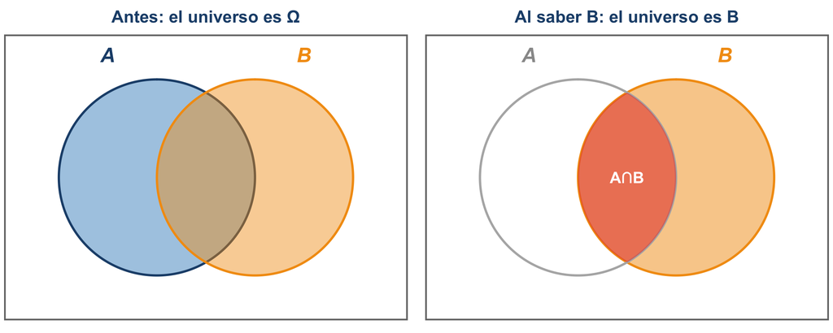

$P(A \mid B)$ compara el área roja ($A \cap B$) con el área total de $B$: lo que queda fuera de $B$ deja de contar.

**Intuición**

Saber que $B$ ocurrió encoge el mundo: la pregunta ya no es “¿qué tan grande es A en todo el universo?” sino “¿qué fracción del territorio de B está ocupada por A?”.

## Independencia: definición y verificación empírica

**Definición:** $A$ y $B$ son independientes si $P(A \cap B) = P(A) \cdot P(B)$, o equivalentemente $P(A \mid B) = P(A)$: saber $B$ no cambia la probabilidad de $A$.

**Verificación en la encuesta:**

$$P(V \cap E) = 0.28 \qquad \text{vs} \qquad P(V) \cdot P(E) = 0.42 \times 0.64 = 0.2688$$

```r
tabla <- matrix(c(140, 70, 180, 110),
                nrow = 2, byrow = TRUE)
round(chisq.test(tabla)$p.value, 3)
```

```
[1] 0.336
```

- No son exactamente independientes, pero la brecha es pequeña y **compatible con el azar** (p $\approx$ 0.34 con n = 500): no hay evidencia contra la independencia.

Asociación no es causalidad, e independencia estadística no implica irrelevancia sustantiva: una tercera variable (edad, ingreso) puede ocultar o inflar la relación observada.

## Regla del producto: muestreo sin reemplazo

$$P(A \cap B) = P(A \mid B) \cdot P(B) = P(B \mid A) \cdot P(A)$$

**Regla en cadena:** $P(A_1 \cap A_2 \cap A_3) = P(A_1) \cdot P(A_2 \mid A_1) \cdot P(A_3 \mid A_1 \cap A_2)$

**Ejemplo — auditoría:** de 20 expedientes, 4 tienen irregularidades. Se auditan 2 al azar **sin reemplazo**:

$$P(\text{ambos irregulares}) = \frac{4}{20} \times \frac{3}{19} = 0.032$$

```r
round(c(dos_irregulares = (4/20) * (3/19),
        al_menos_uno = 1 - (16/20) * (15/19)), 3)
```

```
dos_irregulares    al_menos_uno
          0.032           0.368
```

- La segunda extracción **depende** de la primera: el condicional $3/19$ registra que ya salió un irregular.
- Si los eventos fueran independientes: $P(A \cap B) = P(A) \cdot P(B)$ — caso especial, no regla general.

**Intuición**

Para que ocurran dos cosas en secuencia, la segunda se evalúa en el mundo donde la primera ya pasó: por eso la segunda auditoría enfrenta 3 irregulares entre 19, no 4 entre 20.

## Ley de probabilidad total: promediar sobre una partición

Si $B_1, \ldots, B_k$ particionan $\Omega$ (disjuntos y exhaustivos):

$$P(A) = \sum_{i=1}^{k} P(A \mid B_i) \cdot P(B_i)$$

**Ejemplo:** deserción ($D$) en un programa nacional implementado en tres regiones.

| Región | Peso $P(B_i)$ | Deserción $P(D \mid B_i)$ | Aporte $P(D \cap B_i)$ |
| --- | --- | --- | --- |
| Norte | 0.20 | 0.15 | 0.030 |
| Centro | 0.50 | 0.08 | 0.040 |
| Sur | 0.30 | 0.12 | 0.036 |
| **Total** | 1.00 | — | $P(D) = 0.106$ |

La tasa nacional (10.6%) es un **promedio ponderado** de las tasas regionales. Y de regalo, ya podemos invertir: $P(\text{Norte} \mid D) = 0.030/0.106 = 0.28$ — el Norte aporta 28% de la deserción con solo 20% de los beneficiarios.

## La partición en imágenes: sumar los pedazos de A

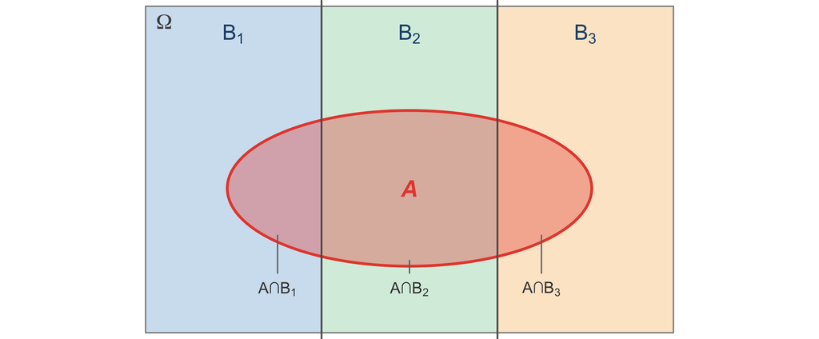

Las bandas $B_1, B_2, B_3$ (las regiones) cubren todo $\Omega$ sin traslaparse; el evento $A$ (desertar) queda cortado en tres pedazos y $P(A)$ es la suma de sus áreas.

**Intuición**

La tasa global es una mezcla: cada región aporta su propia tasa, pesada por su tamaño. Recuperar el total es volver a juntar los pedazos del evento que quedaron en cada banda.

## Teorema de Bayes: derivación en tres pasos

**Paso 1 — la regla del producto, escrita en ambos sentidos:**

$$P(A \cap B) = P(A \mid B) \cdot P(B) \qquad \qquad P(A \cap B) = P(B \mid A) \cdot P(A)$$

**Paso 2 — igualar y despejar:**

$$P(B \mid A) = \frac{P(A \mid B) \cdot P(B)}{P(A)}$$

**Paso 3 — expandir $P(A)$ con probabilidad total** (forma general, con partición $B_1, \ldots, B_k$):

$$P(B_j \mid A) = \frac{P(A \mid B_j) \cdot P(B_j)}{\sum_{i=1}^{k} P(A \mid B_i) \cdot P(B_i)}$$

**Nomenclatura:** $P(B)$ = *prior* · $P(A \mid B)$ = *verosimilitud* · $P(A)$ = *evidencia* · $P(B \mid A)$ = *posterior*. Bayes es la regla para **actualizar creencias con datos**.

**Intuición**

Bayes invierte la pregunta: de “qué tan típica es esta evidencia entre los enfermos” a “qué tan probable es la enfermedad a la vista de la evidencia”. La respuesta mezcla lo que muestra el dato con lo que ya se sabía antes de verlo.

## El árbol del test diagnóstico

**Test para una enfermedad:** prevalencia 0.01, sensibilidad 0.95, especificidad 0.90.

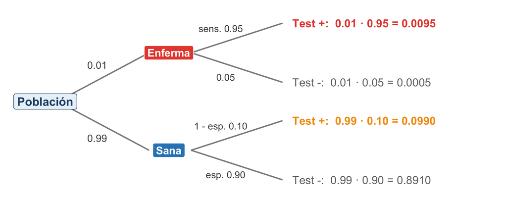

Las ramas “Test +” suman la evidencia $P(+) = 0.0095 + 0.0990 = 0.1085$: los **falsos positivos superan 10 a 1** a los verdaderos.

## P(Enferma | +): el cálculo completo

**Probabilidad total** (denominador de Bayes):

$$P(+) = 0.95 \times 0.01 + 0.10 \times 0.99 = 0.1085$$

**Teorema de Bayes:**

$$P(\text{Enf} \mid +) = \frac{0.95 \times 0.01}{0.1085} = 0.0876$$

```r
prev <- 0.01; sens <- 0.95; esp <- 0.90
p_pos <- sens * prev + (1 - esp) * (1 - prev)
round(c(P_positivo = p_pos,
        P_enf_dado_pos = sens * prev / p_pos), 4)
```

```
    P_positivo P_enf_dado_pos
        0.1085         0.0876
```

Un test con 95% de sensibilidad entrega solo **8.8% de certeza**: de cada 100 positivos, 91 son falsas alarmas. Ignorar la prevalencia es el error de **negligencia de la tasa base**.

## Frecuencias naturales: la misma respuesta sin fórmulas

Imagine **10.000 personas** con las mismas tasas (prevalencia 1%, sensibilidad 95%, especificidad 90%):

|  | Test + | Test - | Total |
| --- | --- | --- | --- |
| Enfermas (100) | 95 | 5 | 100 |
| Sanas (9.900) | 990 | 8.910 | 9.900 |
| Total | 1.085 | 8.915 | 10.000 |

$$P(\text{Enf} \mid +) = \frac{95}{95 + 990} = \frac{95}{1.085} = 0.0876$$

- De cada 1.085 alertas positivas, solo 95 son reales: la baja prevalencia hace que las 990 falsas alarmas de la población sana dominen.
- Gigerenzer: presentar riesgos como **frecuencias naturales** (“95 de cada 1.085”) reduce drásticamente los errores de interpretación de médicos, jueces y policymakers.

## Laboratorio: Teorema de Bayes

Mueva los controles del test diagnóstico y observe cómo el posterior $P(\text{Enf} \mid +)$ responde a la prevalencia, la sensibilidad y la especificidad.

Prevalencia: Sensibilidad: Especificidad:

## Prior → posterior: incluso un test excelente decepciona

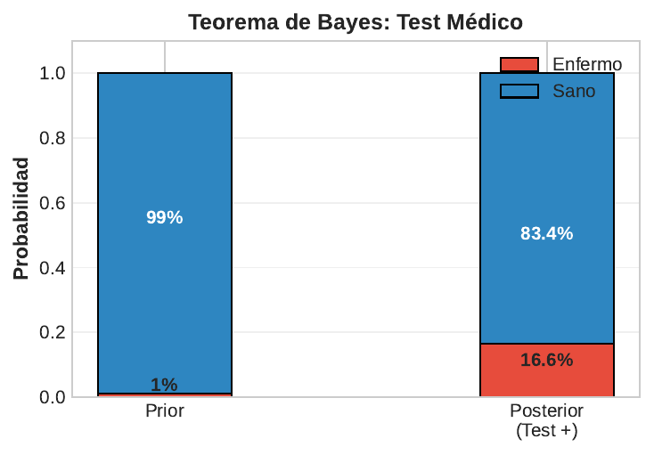

**Un test mejor que el anterior** (sensibilidad 99%, especificidad 95%), misma prevalencia de 1%:

- Prior: $P(\text{Enf}) = 1\%$
- Posterior: $P(\text{Enf} \mid +) \approx 16.6\%$

**Implicancia de política:** en tamizajes masivos de baja prevalencia (cáncer, fraude, dopaje), la mayoría de los positivos serán falsos **aunque el instrumento sea excelente**.

**Solución bayesiana:** repetir el test solo al grupo positivo. Con prior 16.6%, un segundo positivo independiente eleva el posterior a $\approx 80\%$: *el posterior de hoy es el prior de mañana*.

## El posterior depende de la prevalencia

[interactive chart not shown]

Con prevalencia 1%: posterior de 8.8% (FP 10%), 16% (FP 5%) y 49% (FP 1%). Toda curva sobre la diagonal punteada indica que el test **sí aporta información** — pero cuánto, depende del prior.

## La falacia del fiscal

**El error:** confundir $P(\text{evidencia} \mid \text{inocente})$ con $P(\text{inocente} \mid \text{evidencia})$ — la “confusión de la inversa”, el mismo error del test diagnóstico.

**Ejemplo clásico (ADN):** la muestra del sitio coincide con el acusado y el perito declara que la probabilidad de coincidencia por azar es 1 en 1.000.000.

| Cantidad | Valor |
| --- | --- |
| $P(\text{coincidencia} \mid \text{inocente})$ | 1 / 1.000.000 |
| Población plausible de la ciudad | 5.000.000 |
| Coincidencias inocentes esperadas | $\approx 5$ |
| $P(\text{culpable} \mid \text{coincidencia})$ sin otra evidencia | $\approx 1/6 \approx 17\%$ |

El fiscal presenta “1 en un millón” como si fuera la probabilidad de inocencia; Bayes muestra que, sin más evidencia, hay $\approx 6$ personas compatibles y la culpabilidad es $\approx 17\%$. El mismo razonamiento aplica a alertas algorítmicas de fraude y a la vigilancia predictiva.

## Aplicación: detección de fraude en programas sociales

```r
prev <- 0.02; sens <- 0.90
fp <- c(0.05, 0.02, 0.01, 0.005)
post <- sens * prev /
  (sens * prev + fp * (1 - prev))
et <- scales::percent(fp, 0.1)
tibble(
  tasa = factor(et, levels = et),
  post = post) %>%
  ggplot(aes(tasa, post)) +
  geom_col(fill = celeste,
           width = 0.6) +
  geom_text(aes(label =
    scales::percent(post, 1)),
    vjust = -0.4, color = azul) +
  scale_y_continuous(
    labels = scales::percent,
    limits = c(0, 0.95)) +
  labs(x = "Tasa falsos positivos",
       y = "P(fraude | alerta)")
```

[interactive chart not shown]

Algoritmo antifraude: 2% de fraude, sensibilidad 90%. **Reducir los falsos positivos rinde más que subir la sensibilidad**: cada alerta falsa es un beneficiario legítimo suspendido.

## Verificación Monte Carlo del Teorema de Bayes

Simulamos 100.000 personas con las tasas del test diagnóstico y contamos, entre los positivos, cuántos están realmente enfermos:

```r
set.seed(123)
n <- 100000
enfermo <- rbinom(n, 1, 0.01)
p_test <- ifelse(enfermo == 1, 0.95, 0.10)
positivo <- rbinom(n, 1, p_test)
round(c(P_pos_simulada = mean(positivo),
        P_enf_dado_pos_simulada = mean(enfermo[positivo == 1]),
        teorico = 0.0876), 4)
```

```
         P_pos_simulada P_enf_dado_pos_simulada                 teorico
                 0.1089                  0.0898                  0.0876
```

- La frecuencia simulada coincide con el valor teórico: la **ley de grandes números** en acción.
- Método general: cuando la fórmula es intratable (modelos jerárquicos, sistemas complejos), **simular es calcular**. Es la base del análisis bayesiano computacional moderno (MCMC).

**Intuición**

Cuando la fórmula se vuelve intratable, fabrique el mundo cien mil veces en el computador y cuente cuántas veces ocurre el evento: contar reemplaza a integrar.

## De eventos a variables aleatorias

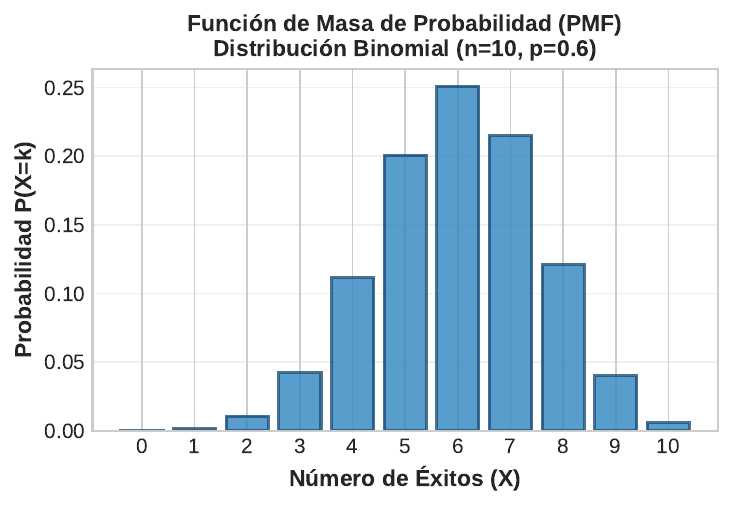

**Variable aleatoria:** función que asigna un número a cada resultado, $X: \Omega \to \mathbb{R}$.

**Función de masa de probabilidad (PMF):**
$$P(X = k) \geq 0, \qquad \sum_k P(X = k) = 1$$

**Ejemplo:** 10 egresados de un programa de empleo, cada uno consigue trabajo con $p = 0.6$ de forma independiente. $X$ = n° de colocados:

$$X \sim \text{Binomial}(10,\, 0.6), \qquad E(X) = np = 6$$

La figura muestra su PMF: el resultado más probable es 6, pero valores entre 4 y 8 concentran casi toda la masa.

## Errores comunes al razonar con incertidumbre

| Error | Ejemplo | Corrección |
| --- | --- | --- |
| Negligencia de la tasa base | “El test es 95% sensible, luego estoy 95% enfermo” | Teorema de Bayes con el prior |
| Falacia del fiscal | Condenar porque $P(\text{evidencia} \mid \text{inocente})$ es pequeña | Calcular $P(\text{inocente} \mid \text{evidencia})$ |
| Confusión de la inversa | Reportar $P(A \mid B)$ como si fuera $P(B \mid A)$ | Tabla de frecuencias naturales |
| Asumir independencia | Multiplicar riesgos correlacionados | Verificar $P(A \cap B) = P(A)P(B)$ |
| Sumar sin restar intersección | Proporciones que suman más de 100% | Inclusión-exclusión |
| Asociación leída como causa | “La educación causa el voto” desde una tabla | Diseños causales (econometría) |

## Síntesis: qué llevarse de esta sesión

**Checklist para razonar con probabilidades**

1. Definir $\Omega$ y los eventos sin ambigüedad
2. Distinguir conjunta, marginal y condicional
3. Nunca asumir independencia: verificarla
4. Ante un condicional invertido, aplicar Bayes
5. Comunicar con frecuencias naturales
6. Simular (Monte Carlo) para verificar cálculos
7. Recordar: el posterior depende del prior

**Funciones R de esta sesión**

`sample()` `rbinom()` `cumsum()` `mean()` `table()` `prop.table()` `chisq.test()` `set.seed()` `ifelse()` `crossing()`

**Fórmula estrella:**
$$P(B \mid A) = \frac{P(A \mid B) P(B)}{P(A)}$$

**Próxima sesión:** distribuciones de probabilidad (Binomial, Poisson, Normal).

## Ejercicio para practicar (30 min)

**Escenario:** test de drogas para conductores de transporte escolar. Prevalencia de consumo: 0.5%; sensibilidad: 98%; especificidad: 97%.

1. Dibuje el árbol de probabilidades y calcule $P(+)$ con la ley de probabilidad total.
2. Calcule $P(\text{consumo} \mid +)$ con el Teorema de Bayes. ¿Le sorprende el resultado?
3. Construya la tabla de frecuencias naturales para 100.000 conductores y verifique el valor.
4. ¿Desde qué prevalencia el posterior supera 50%? (Pista: iguale verdaderos y falsos positivos.)
5. Simule el escenario en R con `rbinom()` (n = 100.000, con `set.seed()`) y compare con el valor teórico.
6. Discuta: ¿qué protocolo recomendaría tras un positivo — despido inmediato o test confirmatorio? Justifique con los números.

**Referencias:** Blitzstein & Hwang, *Introduction to Probability* (caps. 1–2) · Gigerenzer, *Calculated Risks* · Illowsky & Dean, *Introductory Statistics* (caps. 3–4).